# Random Variable

# Random Variable

A random variable is a function mapping from the sample space to the real line.

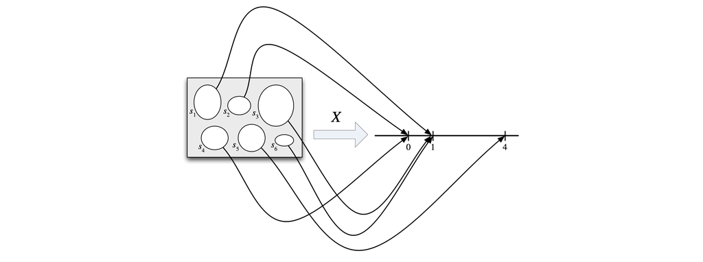

Random variable

# Discrete

Discrete Random variable

Given a random variable, we would like to be able to describe its behavior using the language of probability. For example, we might want to answer questions about the probability that the r.v. will fall into a given range

- if L is the lifetime earnings of a randomly chosen U.S. college graduate, what is the probability that L exceeds a million dollars?
- If M is the number of major earthquakes in California in the next five years, what is the probability that M equals 0?

The distribution of a random variable provides the answers to these questions; it specifies the probabilities of all events associated with the r.v., such as the probability of it equaling 3 and the probability of it being at least 110. For a discrete r.v., the most natural way to do so is with a Probability Mass Function.